# Analyzing consequences of weather events in the US between 1950 and 2011

## Data Processing

We initially load some libraries useful for processing the data and displaying the results.

```r
library(dplyr)
```

```r
library(ggplot2)
library(lubridate)
```

The data was downloaded from https://d396qusza40orc.cloudfront.net/repdata%2Fdata%2FStormData.csv.bz2 The data is then read using the `read.csv`

```r
data <- read.csv(bzfile("repdata-data-StormData.csv.bz2"), header = TRUE)
```

We then remove all the observations where there is no damage (population or property) caused. To achieve this we filter out rows which have 0s in all the 4 columns below :

- FATALITIES
- INJURIES
- PROPDMG
- CROPDMG

We do this so as to reduce the size of the data which we need to process. We also are trying to analyze the events which caused damages to property and poulation and hence other observations are irrlevant in the scope of this report.

We also convert the EVTYPE column into a charcter column since we need to group by it for further results.

```r
harmful_data <- data %>%
  filter(FATALITIES != 0 | INJURIES != 0 | PROPDMG != 0 | CROPDMG != 0)
harmful_data$EVTYPE = as.character(harmful_data$EVTYPE)
```

## Results

### Events causing greatest harm to population

In order to find the events which caused the greatest harm to the population we first add a column which contains the sum of the fatalities and injuries for each of the observations. We then find the sum of of this column `population_damage`, grouped by events to give the total population damage per event. We then arrange this in the descending order and take the top 6 rows which give the most damaging events. The list here is a consolidated list for both injuries and fatalities.

```r
population_damage_byevent <- harmful_data %>%
  mutate(population_damage = FATALITIES + INJURIES) %>%
  group_by(EVTYPE) %>%
  summarize(total_damage = sum(population_damage)) %>%
  arrange(desc(total_damage))
head(population_damage_byevent)
```

```
## Source: local data frame [6 x 2]
##
##           EVTYPE total_damage
## 1        TORNADO        96979
## 2 EXCESSIVE HEAT         8428
## 3      TSTM WIND         7461
## 4          FLOOD         7259
## 5      LIGHTNING         6046
## 6           HEAT         3037
```

We take the summary obtained above and plot it in a barplot.

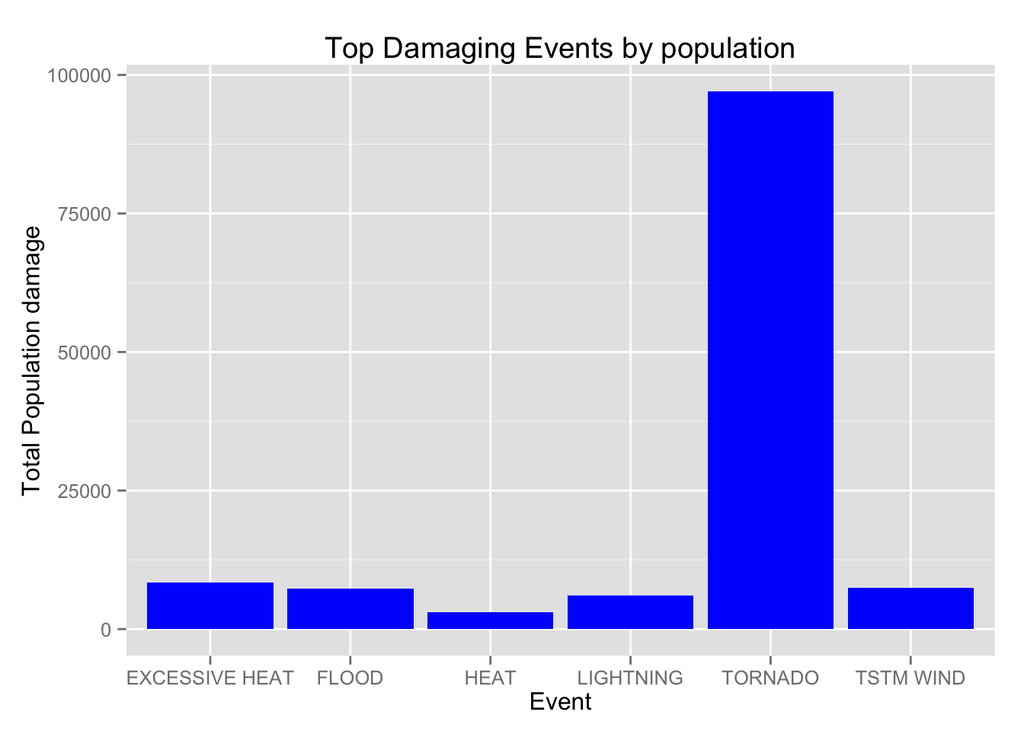

```r
top_damaging_events <- head(population_damage_byevent)
gp <- ggplot(data = top_damaging_events, aes (x = EVTYPE, y = total_damage)) + geom_bar(fill = "blue", stat = "identity") + xlab("Event") + ylab("Total Population damage") + ggtitle("Top Damaging Events by population")
print(gp)
```

### Events causing greatest economic harm

In order to find the weather events which cause the greatest economic harm, we look at the damage caused to two things :

- Property
- Crops

These are represented by the PROPDMG and CROPDMG columns. The PROPDMGEXP and CROPDMGEXP columns are used an exponent columns. The values “K”, “M” and “B” are taken to be thousand, million and a billion multipliers respectively. We first compute this and store in a DF called `harmful_data_1`

```r
harmful_data_1 <- harmful_data %>%
  mutate(propdmg_actual = (ifelse(toupper(PROPDMGEXP) == 'K', PROPDMG * 10^3,
                           ifelse(toupper(PROPDMGEXP) == 'M', PROPDMG * 10^6,
                           ifelse(toupper(PROPDMGEXP) == 'B', PROPDMG * 10^9,
                            PROPDMG)))
                           )) %>%
    mutate(cropdmg_actual = (ifelse(toupper(CROPDMGEXP) == 'K', CROPDMG * 10^3,
                           ifelse(toupper(CROPDMGEXP) == 'M', CROPDMG * 10^6,
                           ifelse(toupper(CROPDMGEXP) == 'B', CROPDMG * 10^9,
                            CROPDMG)))
                           ))
```

This is then used to compute the top events causing most economic consequences by aggregating on the sum of the property damage and crop damage. We then print out the head of the resulting df which shows the events which caused the most damage to the economy.

```r
economic_damage_byevent <- harmful_data_1 %>%
  mutate(total_property_dmg = propdmg_actual + cropdmg_actual) %>%
  group_by(EVTYPE) %>%
  summarize(total_dmg = sum(total_property_dmg)) %>%
  arrange(desc(total_dmg))

head(economic_damage_byevent)
```

```
## Source: local data frame [6 x 2]
##
##              EVTYPE    total_dmg
## 1             FLOOD 150319678257
## 2 HURRICANE/TYPHOON  71913712800
## 3           TORNADO  57352114049
## 4       STORM SURGE  43323541000
## 5              HAIL  18758221521
## 6       FLASH FLOOD  17562129167
```

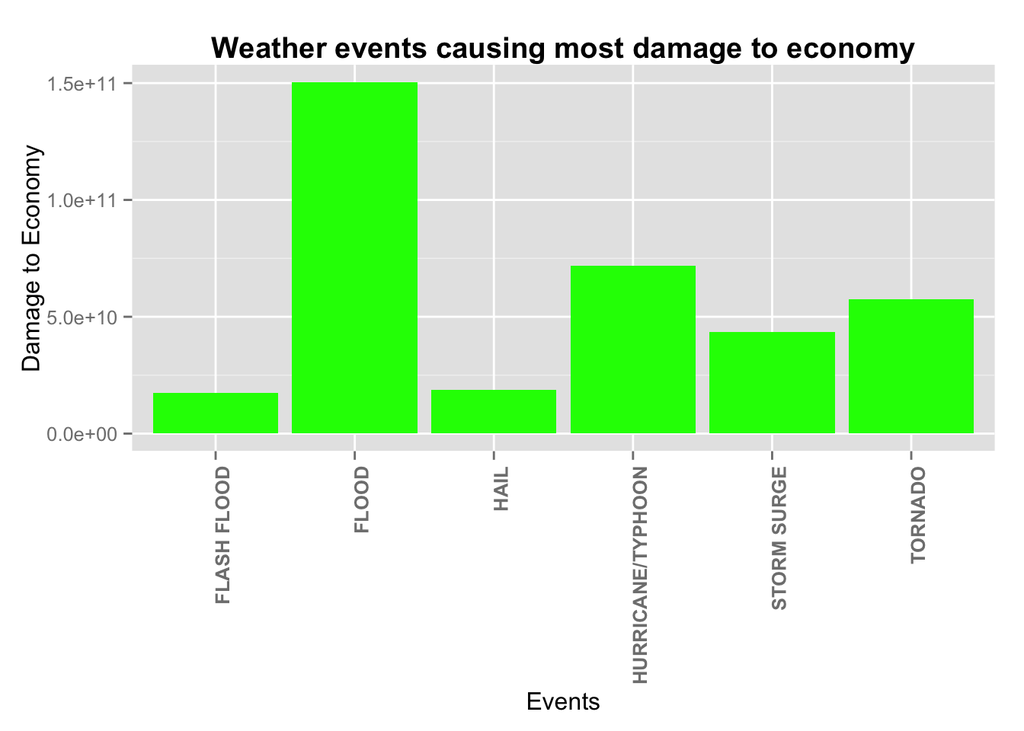

```r
top_dmg_events_economic <- head(economic_damage_byevent)
gp <- ggplot(data = top_dmg_events_economic, aes(x = EVTYPE, y = total_dmg)) +
  geom_bar(fill = "green", stat = "identity") +
  theme(axis.text.x = element_text(angle = 90, hjust = 1, face = "bold"),
          plot.title = element_text(face="bold")
          ) +
  xlab("Events") +
  ylab("Damage to Economy") +
  ggtitle("Weather events causing most damage to economy")
print(gp)
```